# Rebekah Tweets

Richard G. Gardiner

11/12/2018

## Load and Clean Data

loading the data:

```r
tweets <- read_excel("2016 2017 Pres Tweets.xlsx")
```

Capturing if they have a Retweet

```r
tweets$rt <- str_detect(tweets$Tweet, "^RT ")

head(tweets$rt)
```

```
## [1]  TRUE  TRUE FALSE FALSE FALSE FALSE
```

## Cleaning and removing stop words

Here we are removing text that does not have any real meaning and is extremely common. These include the most common words like: “the”, “and”, “or”. Rather than using a regular tokenizer, we are using the tokenizer that was specially created for tweets (Mullen 2016).

```r
remove_reg <- "&amp;|&lt;|&gt;"

tidy_tweets <- tweets %>%
#  filter(!str_detect(text, "^RT")) %>% # this removes any retweets, right now we are keeping them in
  mutate(text = str_remove_all(Tweet, remove_reg)) %>%
  unnest_tokens(word, text, token = "tweets") %>%
  filter(!word %in% stop_words$word,
         !word %in% str_remove_all(stop_words$word, "'"),
         str_detect(word, "[a-z]"))
```

I am now creating a dataframe of all tweets that contain a “#”. Then I am saving both as a csv to send to Rebekah

```r
hashtags <- tidy_tweets %>%
  filter(str_detect(word, "#"))

#write_csv(tidy_tweets, "tweets4initialLooks.csv")
#write_csv(hashtags, "hashtags.csv")
```

Now we can use the tidy tools to plot the most common words

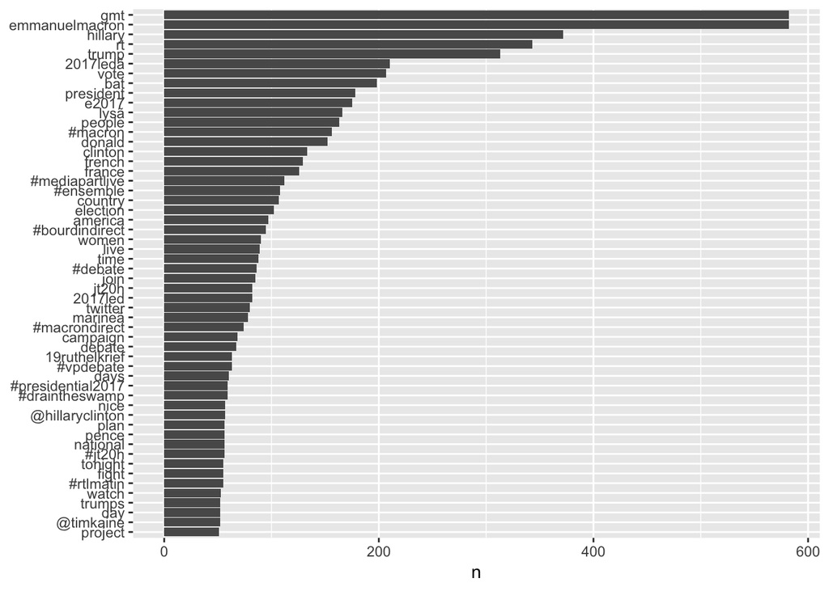

```r
tidy_tweets %>%
  count(word, sort = TRUE) %>%
  filter(n > 50) %>%
  mutate(word = reorder(word, n)) %>%
  ggplot(aes(word, n)) +
  geom_col() +
  xlab(NULL) +
  coord_flip()
```

There really isn’t anything that scares me. There is a word at the bottom that I don’t really know the meaning of. Now I want to do this again, but for each candidate:

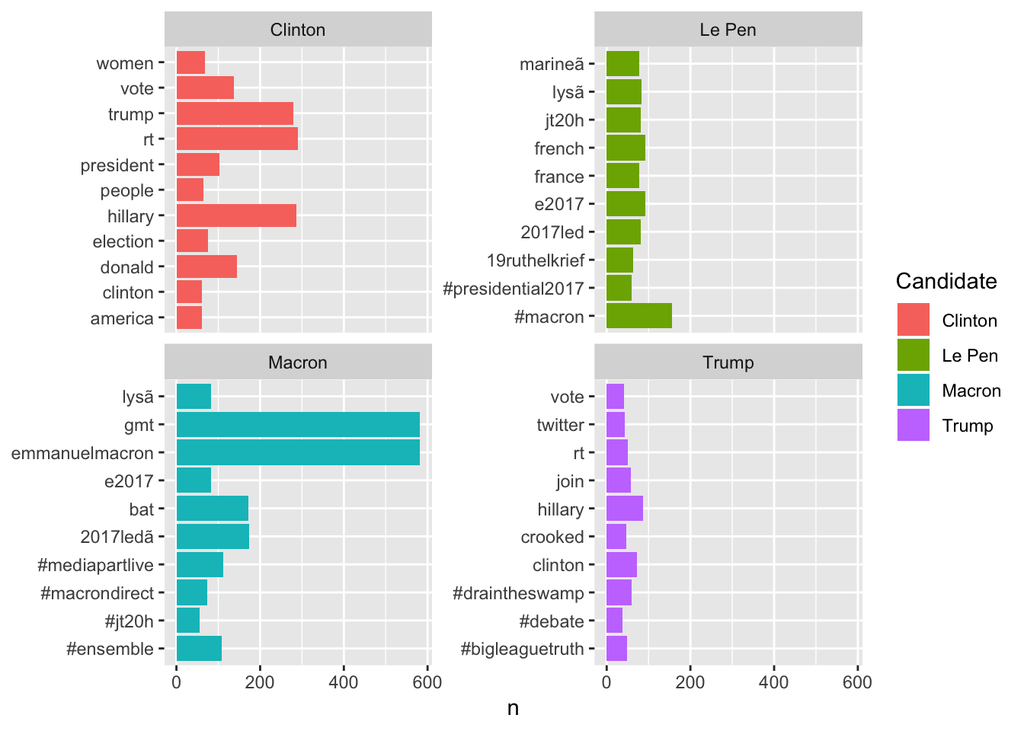

```r
tidy_tweets %>%
  group_by(Candidate) %>%
  count(word, sort = TRUE) %>%
  top_n(10) %>%
  mutate(word = reorder(word, n)) %>%
  ggplot(aes(word, n, fill = Candidate)) +
  geom_col() +
  xlab(NULL) +
  coord_flip() +
  facet_wrap(~ Candidate, scales = "free_y")
```

## January 21, 2019

I am looking at Rebekah’s work on the hashtags. It is a great step forward by taking out the hashtags and removing the weird characters that sometimes occur, one potential problem I see is that many of the hastags are not separated into individual words (“borderwall”). The reason this does not work for sentiment analysis is because the sentiment analysis dictionary looks for exact matches. So if the dictionary sees “borderwall” it will come back as not having a match when in reality it should be matched with “border” and “wall”. Now this might not be the most important because the hashtags are found in the raw count for each individual (the figure right above), and they might not even have a sentiment tied to the words. I am going to try to see what can be done with what we currently have.

### Taking out the hashtags

This takes out the actual “#” but keeps the words together. This will at least partially fix the problem.

```r
tidy_tweets$word <- str_replace(tidy_tweets$word, "#", "")
```

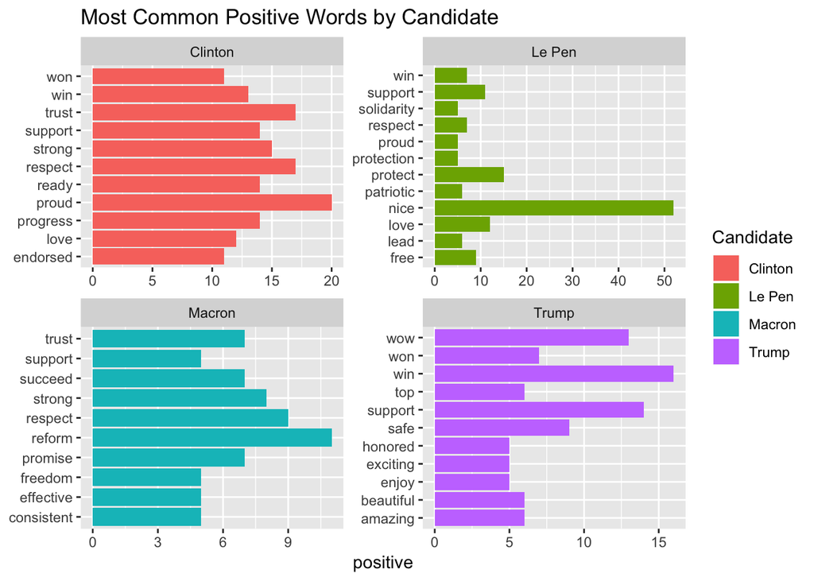

```r
sentiments <- tidy_tweets %>%
  left_join(get_sentiments("bing"), by = "word")

sentiments$positive <- ifelse(sentiments$sentiment == "positive", 1, 0)
sentiments$negative <- ifelse(sentiments$sentiment == "negative", 1, 0)

sentiments %>%
  group_by(Candidate, word) %>%
  summarise(positive = sum(positive),
            negative = sum(negative)) %>%
  filter(word != "trump") %>% # trump is listed as positive, so I took it out
  top_n(10, positive) %>%
  mutate(word = reorder(word, positive)) %>%
  ggplot(aes(word, positive, fill = Candidate)) +
  geom_col() +
  xlab(NULL) +
  coord_flip() +
  facet_wrap(~ Candidate, scales = "free") +
  ggtitle("Most Common Positive Words by Candidate")
```

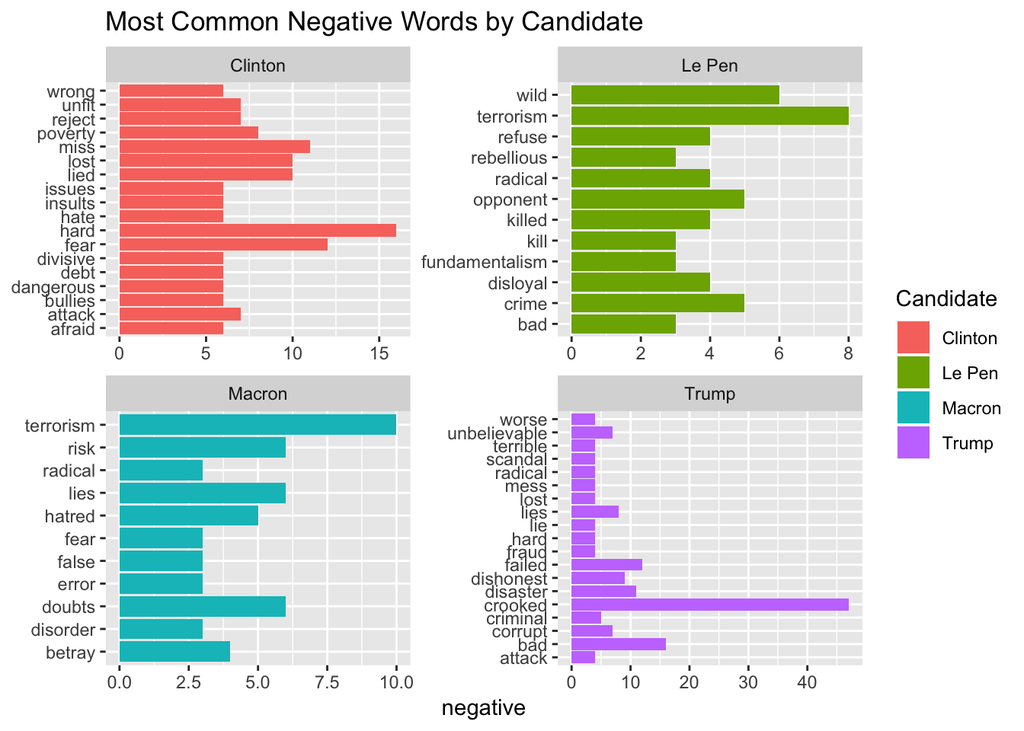

```r
sentiments %>%
  group_by(Candidate, word) %>%
  summarise(positive = sum(positive),
            negative = sum(negative)) %>%
  filter(word != "trump") %>% # trump is listed as positive, so I took it out
  top_n(10, negative) %>%
  mutate(word = reorder(word, negative)) %>%
  ggplot(aes(word, negative, fill = Candidate)) +
  geom_col() +
  xlab(NULL) +
  coord_flip() +
  facet_wrap(~ Candidate, scales = "free") +
  ggtitle("Most Common Negative Words by Candidate")
```

```r
sentiments %>%
  group_by(Candidate, word) %>%
  summarise(positive = sum(positive),
            negative = sum(negative)) %>%
  arrange(desc(positive)) %>%
  ungroup() %>%
  filter(!str_detect(word, "trump")) %>%
  group_by(Candidate) %>%
  mutate(sentiment_score = positive - negative) %>%
  filter(!is.na(sentiment_score)) %>%
  summarise(total = sum(sentiment_score))
```

```
## # A tibble: 4 x 2
##   Candidate  total
##   <chr>      <dbl>
## 1 Clinton     29.0
## 2 Le Pen      45.0
## 3 Macron      47.0
## 4 Trump     -108
```

Trump was by far more negative than Clinton whereas Macron was about the same as Le Pen, but this is likely due to the nature of the unigram analysis and the influence of the translation.

### Frequencies

Now let’s caculate word frequencies for each person. First, we group by person and count how many times each person used each word. Then use `left_join()` to add a column of the totla number of words used by each person. Finally we calculate a frequency for each person and word.

```r
frequency <- tidy_tweets %>%
  group_by(Candidate) %>%
  filter(!str_detect(word, "^@")) %>%
  count(word, sort = TRUE) %>%
  left_join(tidy_tweets %>%
              group_by(Candidate) %>%
              summarise(total = n())) %>%
  mutate(freq = n/total)
frequency
```

```
## # A tibble: 10,382 x 5
## # Groups:   Candidate [4]
##    Candidate word               n total   freq
##    <chr>     <chr>          <int> <int>  <dbl>
##  1 Macron    emmanuelmacron   582  6087 0.0956
##  2 Macron    gmt              582  6087 0.0956
##  3 Clinton   rt               290 11509 0.0252
##  4 Clinton   hillary          286 11509 0.0249
##  5 Clinton   trump            280 11509 0.0243
##  6 Le Pen    macron           178  4775 0.0373
##  7 Macron    2017ledã         174  6087 0.0286
##  8 Macron    bat              171  6087 0.0281
##  9 Clinton   donald           145 11509 0.0126
## 10 Clinton   vote             138 11509 0.0120
## # ... with 10,372 more rows
```

In order to plot the information learned above we use use the `spread()` function to make a differently shaped data frame:

```r
frequency <- frequency %>%
  select(Candidate, word, freq) %>%
  spread(Candidate, freq) %>%
  arrange(Clinton, Trump, Macron, `Le Pen`)

frequency
```

```
## # A tibble: 8,337 x 5
##    word           Clinton  `Le Pen`   Macron    Trump
##    <chr>            <dbl>     <dbl>    <dbl>    <dbl>
##  1 directly     0.0000869  0.000209 0.000164 0.000184
##  2 opposed      0.0000869  0.000209 0.000164 0.000184
##  3 solutions    0.0000869  0.000209 0.000164 0.000184
##  4 gratitude    0.0000869  0.000838 0.000164 0.000184
##  5 advance      0.0000869 NA        0.000164 0.000184
##  6 announcement 0.0000869 NA        0.000164 0.000184
##  7 damage       0.0000869 NA        0.000164 0.000184
##  8 dream        0.0000869 NA        0.000164 0.000184
##  9 impact       0.0000869 NA        0.000164 0.000184
## 10 information  0.0000869 NA        0.000164 0.000184
## # ... with 8,327 more rows
```

```r
library(scales)
```

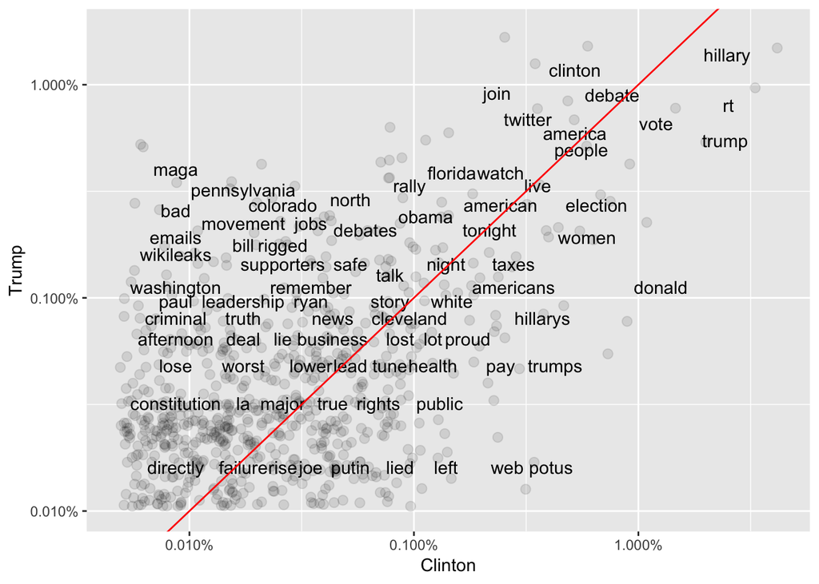

```r
ggplot(frequency, aes(Clinton, Trump)) +
  geom_jitter(alpha = 0.1, size = 2.5, width = .25, height = 0.25) +
  geom_text(aes(label = word), check_overlap = TRUE, vjust = 1.5) +
  scale_x_log10(labels = percent_format()) +
  scale_y_log10(labels = percent_format()) +
  geom_abline(color = "red")
```

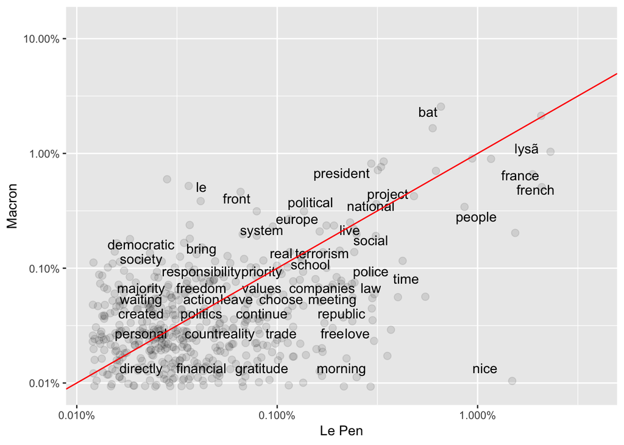

```r
ggplot(frequency, aes(`Le Pen`, Macron)) +
  geom_jitter(alpha = 0.1, size = 2.5, width = .25, height = 0.25) +
  geom_text(aes(label = word), check_overlap = TRUE, vjust = 1.5) +
  scale_x_log10(labels = percent_format()) +
  scale_y_log10(labels = percent_format()) +
  geom_abline(color = "red")
```

Words near the line are used with about equal frequencies by both individuals. While words far away from the line are used much more by one person compared to the other. Words, hashtags, and usernames that appear in this plot are ones that have been used by both individuals at least once in a tweet.

## Side research not to be included in final:

The charts above got me asking: how often did the candidate reference the other person?

```r
trump <- tidy_tweets %>%
  filter(str_detect(word, "^trump"))

table(trump$Candidate)
```

```
##
## Clinton   Trump
##     349      51
```

```r
hillary <- tidy_tweets %>%
  filter(str_detect(word, "^hillary"))
table(hillary$Candidate)
```

```
##
## Clinton   Trump
##     378     115
```

```r
table(tweets$Candidate)
```

```
##
## Clinton  Le Pen  Macron   Trump
##    1339     484     989     646
```

I thought the second to last one was interesting so I wanted to quickly check the usage, and found that Clinton has the most tweets (by far) of any candidate. This is why we are getting the outcome above. Can’t probably use this in a report.